# FINAL ASSIGNMENT

# Data Cleaning & Handling Missingness

```r
#libraries
library(tidyverse)
library(randomForest)
library(gbm)
library(pROC)
library(tidyr)
library(ggplot2)
```

```r
#reading data
stroke_data <- read.csv("stroke.csv", na.strings = c("N/A", "NA", ""))
```

```r
head(stroke_data)
```

```
##      id gender age hypertension heart_disease ever_married     work_type
## 1  9046   Male  67            0             1          Yes       Private
## 2 51676 Female  61            0             0          Yes Self-employed
## 3 31112   Male  80            0             1          Yes       Private
## 4 60182 Female  49            0             0          Yes       Private
## 5  1665 Female  79            1             0          Yes Self-employed
## 6 56669   Male  81            0             0          Yes       Private
##   Residence_type avg_glucose_level  bmi  smoking_status stroke
## 1          Urban            228.69 36.6 formerly smoked      1
## 2          Rural            202.21   NA    never smoked      1
## 3          Rural            105.92 32.5    never smoked      1
## 4          Urban            171.23 34.4          smokes      1
## 5          Rural            174.12 24.0    never smoked      1
## 6          Urban            186.21 29.0 formerly smoked      1
```

```r
str(stroke_data)
```

```
## 'data.frame':    5110 obs. of  12 variables:
##  $ id               : int  9046 51676 31112 60182 1665 56669 53882 10434 27419 60491 ...
##  $ gender           : chr  "Male" "Female" "Male" "Female" ...
##  $ age              : num  67 61 80 49 79 81 74 69 59 78 ...
##  $ hypertension     : int  0 0 0 0 1 0 1 0 0 0 ...
##  $ heart_disease    : int  1 0 1 0 0 0 1 0 0 0 ...
##  $ ever_married     : chr  "Yes" "Yes" "Yes" "Yes" ...
##  $ work_type        : chr  "Private" "Self-employed" "Private" "Private" ...
##  $ Residence_type   : chr  "Urban" "Rural" "Rural" "Urban" ...
##  $ avg_glucose_level: num  229 202 106 171 174 ...
##  $ bmi              : num  36.6 NA 32.5 34.4 24 29 27.4 22.8 NA 24.2 ...
##  $ smoking_status   : chr  "formerly smoked" "never smoked" "never smoked" "smokes" ...
##  $ stroke           : int  1 1 1 1 1 1 1 1 1 1 ...
```

```r
dim(stroke_data)
```

```
## [1] 5110   12
```

- The dataset contains 5110 observations and 12 variables.
- Variables include demographics (age, gender), medical history (hypertension, heart disease), lifestyle (smoking), and outcome (stroke).
- The outcome variable stroke is binary (0 = No stroke, 1 = Stroke).
- Initial inspection shows missing values in BMI.

```r
#removing ID column
stroke_data <- stroke_data %>%
  select(-id)
```

- The ID column was removed since it does not contribute to prediction.

```r
#converting variables
stroke_data <- stroke_data %>%
  mutate(
    gender = as.factor(gender),
    hypertension = as.factor(hypertension),
    heart_disease = as.factor(heart_disease),
    ever_married = as.factor(ever_married),
    work_type = as.factor(work_type),
    Residence_type = as.factor(Residence_type),
    smoking_status = as.factor(smoking_status),
    stroke = as.factor(stroke)
  )
#bmi to numeric
stroke_data$bmi <- as.numeric(stroke_data$bmi)
```

- Categorical variables were converted into factors, which is necessary for classification models.
- BMI was ensured to be numeric.

```r
#missing values
missing_count <- colSums(is.na(stroke_data))
missing_percent <- round(colMeans(is.na(stroke_data)) * 100, 2)

missing_summary <- data.frame(
  Variable = names(stroke_data),
  Missing_Count = missing_count,
  Missing_Percent = missing_percent
)
missing_summary
```

```
##                            Variable Missing_Count Missing_Percent
## gender                       gender             0            0.00
## age                             age             0            0.00
## hypertension           hypertension             0            0.00
## heart_disease         heart_disease             0            0.00
## ever_married           ever_married             0            0.00
## work_type                 work_type             0            0.00
## Residence_type       Residence_type             0            0.00
## avg_glucose_level avg_glucose_level             0            0.00
## bmi                             bmi           201            3.93
## smoking_status       smoking_status             0            0.00
## stroke                       stroke             0            0.00
```

- Only BMI had missing values (201 cases, ~3.93%).
- All other variables had no missing data.

```r
#imputing missing BMI using median
median_bmi <- median(stroke_data$bmi, na.rm = TRUE)
stroke_data$bmi[is.na(stroke_data$bmi)] <- median_bmi
```

- Missing BMI values were replaced using the median BMI.

```r
#missing values check after imputing
missing_count <- colSums(is.na(stroke_data))
missing_percent <- round(colMeans(is.na(stroke_data)) * 100, 2)

missing_summary <- data.frame(
  Variable = names(stroke_data),
  Missing_Count = missing_count,
  Missing_Percent = missing_percent
)
missing_summary
```

```
##                            Variable Missing_Count Missing_Percent
## gender                       gender             0               0
## age                             age             0               0
## hypertension           hypertension             0               0
## heart_disease         heart_disease             0               0
## ever_married           ever_married             0               0
## work_type                 work_type             0               0
## Residence_type       Residence_type             0               0
## avg_glucose_level avg_glucose_level             0               0
## bmi                             bmi             0               0
## smoking_status       smoking_status             0               0
## stroke                       stroke             0               0
```

- After imputation, no missing values remain.

# Train & Test Data Split

```r
set.seed(123)
```

```r
#70-30
train_index <- sample(1:nrow(stroke_data), size = 0.7 * nrow(stroke_data))
```

```r
#training data
train_data <- stroke_data[train_index, ]
dim(train_data)
```

```
## [1] 3577   11
```

```r
#testing data
test_data  <- stroke_data[-train_index, ]
dim(test_data)
```

```
## [1] 1533   11
```

Data split into:

- 70% training (3577 observations)
- 30% testing (1533 observations)

```r
#class distribution
table(stroke_data$stroke)
```

```
##
##    0    1
## 4861  249
```

```r
#class distribution in training data
table(train_data$stroke)
```

```
##
##    0    1
## 3408  169
```

```r
#class distribution in testing data
table(test_data$stroke)
```

```
##
##    0    1
## 1453   80
```

Stroke cases:

- No stroke (0): 4861
- Stroke (1): 249

This shows the data set includes severe class imbalance (~5% stroke cases).

# Logistic Regression Model

```r
# Fit LRM
model_log <- glm(stroke ~ ., data = train_data, family = "binomial")
summary(model_log)
```

```
##
## Call:
## glm(formula = stroke ~ ., family = "binomial", data = train_data)
##
## Coefficients:
##                              Estimate Std. Error z value Pr(>|z|)
## (Intercept)                -6.895e+00  1.084e+00  -6.362 1.99e-10 ***
## genderMale                 -6.566e-03  1.720e-01  -0.038  0.96955
## genderOther                -1.061e+01  1.455e+03  -0.007  0.99418
## age                         7.569e-02  7.088e-03  10.679  < 2e-16 ***
## hypertension1               4.454e-01  1.988e-01   2.241  0.02502 *
## heart_disease1              2.330e-01  2.375e-01   0.981  0.32651
## ever_marriedYes            -1.803e-01  2.702e-01  -0.667  0.50452
## work_typeGovt_job          -7.981e-01  1.140e+00  -0.700  0.48376
## work_typeNever_worked      -9.992e+00  3.748e+02  -0.027  0.97873
## work_typePrivate           -5.502e-01  1.119e+00  -0.492  0.62287
## work_typeSelf-employed     -1.164e+00  1.145e+00  -1.017  0.30918
## Residence_typeUrban         9.043e-02  1.676e-01   0.540  0.58945
## avg_glucose_level           4.404e-03  1.433e-03   3.073  0.00212 **
## bmi                        -4.703e-03  1.397e-02  -0.337  0.73636
## smoking_statusnever smoked -2.012e-01  2.091e-01  -0.962  0.33594
## smoking_statussmokes        5.160e-02  2.579e-01   0.200  0.84142
## smoking_statusUnknown      -2.719e-01  2.627e-01  -1.035  0.30056
## ---
## Signif. codes:  0 '***' 0.001 '**' 0.01 '*' 0.05 '.' 0.1 ' ' 1
##
## (Dispersion parameter for binomial family taken to be 1)
##
##     Null deviance: 1361.6  on 3576  degrees of freedom
## Residual deviance: 1080.4  on 3560  degrees of freedom
## AIC: 1114.4
##
## Number of Fisher Scoring iterations: 14
```

```r
# Predict probabilities on test data
pred_prob_log <- predict(model_log, newdata = test_data, type = "response")

# Converting probabilities to class (0/1) using 0.5 threshold
pred_class_log <- ifelse(pred_prob_log > 0.2, 1, 0)
```

- The logistic regression model identified age, hypertension, and average glucose level as significant predictors of stroke.
- Increasing age and higher glucose levels were associated with increased stroke risk.
- However, most other variables were not statistically significant, and model performance was limited.

```r
#confusion matrix
cm_log_standard <- table(
  Predicted = factor(pred_class_log, levels = c(1, 0)),
  Actual = factor(test_data$stroke, levels = c(1, 0))
)
cm_log_standard
```

```
##          Actual
## Predicted    1    0
##         1   21   60
##         0   59 1393
```

# Random Forest Model

```r
# Fit RFM
model_rf <- randomForest(stroke ~ ., data = train_data, ntree = 100)
print(model_rf)
```

```
##
## Call:
##  randomForest(formula = stroke ~ ., data = train_data, ntree = 100)
##                Type of random forest: classification
##                      Number of trees: 100
## No. of variables tried at each split: 3
##
##         OOB estimate of  error rate: 4.78%
## Confusion matrix:
##      0 1 class.error
## 0 3404 4 0.001173709
## 1  167 2 0.988165680
```

```r
# Predict probabilities on test data
pred_prob_rf <- predict(model_rf, newdata = test_data, type = "prob")[,2]

# Converting class
pred_class_rf <- ifelse(pred_prob_rf > 0.2, 1, 0)
pred_class_rf <- as.factor(pred_class_rf)
```

```r
# Confusion matrix
cm_rf_standard <- table(
  Predicted = factor(pred_class_rf, levels = c(1, 0)),
  Actual = factor(test_data$stroke, levels = c(1, 0))
)
cm_rf_standard
```

```
##          Actual
## Predicted    1    0
##         1   16   75
##         0   64 1378
```

# Gradient Boosting Model

```r
train_gbm <- train_data
test_gbm  <- test_data

train_gbm$stroke <- as.numeric(as.character(train_gbm$stroke))
test_gbm$stroke  <- as.numeric(as.character(test_gbm$stroke))

# Fit GBM
model_gbm <- gbm(stroke ~ .,data = train_gbm, distribution = "bernoulli", n.trees = 100,
  interaction.depth = 3, shrinkage = 0.01, n.minobsinnode = 10, verbose = FALSE)

# predict probabilities
pred_prob_gbm <- predict(model_gbm, newdata = test_gbm, n.trees = 100, type = "response")

# convert probabilities to class
pred_class_gbm <- ifelse(pred_prob_gbm > 0.2, 1, 0)
```

```r
# confusion matrix
cm_gbm_standard <- table(
  Predicted = factor(pred_class_gbm, levels = c(1, 0)),
  Actual = factor(test_gbm$stroke, levels = c(1, 0))
)

cm_gbm_standard
```

```
##          Actual
## Predicted    1    0
##         1    3   15
##         0   77 1438
```

# Model Comparison

```r
#Logistic Regression
TP_log <- cm_log_standard["1","1"]
FP_log <- cm_log_standard["1","0"]
FN_log <- cm_log_standard["0","1"]
TN_log <- cm_log_standard["0","0"]

accuracy_log <- (TP_log + TN_log) / sum(cm_log_standard)
sensitivity_log <- TP_log / (TP_log + FN_log)
specificity_log <- TN_log / (TN_log + FP_log)

auc_log <- auc(roc(test_data$stroke, pred_prob_log))
accuracy_log
```

```
## [1] 0.9223744
```

```r
sensitivity_log
```

```
## [1] 0.2625
```

```r
specificity_log
```

```
## [1] 0.9587061
```

```r
auc_log
```

```
## Area under the curve: 0.841
```

```r
#Random Forest
TP_rf <- cm_rf_standard["1","1"]
FP_rf <- cm_rf_standard["1","0"]
FN_rf <- cm_rf_standard["0","1"]
TN_rf <- cm_rf_standard["0","0"]

accuracy_rf <- (TP_rf + TN_rf) / sum(cm_rf_standard)
sensitivity_rf <- TP_rf / (TP_rf + FN_rf)
specificity_rf <- TN_rf / (TN_rf + FP_rf)

auc_rf <- auc(roc(test_data$stroke, pred_prob_rf))
accuracy_rf
```

```
## [1] 0.9093281
```

```r
sensitivity_rf
```

```
## [1] 0.2
```

```r
specificity_rf
```

```
## [1] 0.9483827
```

```r
auc_rf
```

```
## Area under the curve: 0.81
```

```r
#Gradient Boosting
TP_gbm <- cm_gbm_standard["1","1"]
FP_gbm <- cm_gbm_standard["1","0"]
FN_gbm <- cm_gbm_standard["0","1"]
TN_gbm <- cm_gbm_standard["0","0"]

accuracy_gbm <- (TP_gbm + TN_gbm) / sum(cm_gbm_standard)
sensitivity_gbm <- TP_gbm / (TP_gbm + FN_gbm)
specificity_gbm <- TN_gbm / (TN_gbm + FP_gbm)

auc_gbm <- auc(roc(test_gbm$stroke, pred_prob_gbm))
accuracy_gbm
```

```
## [1] 0.939987
```

```r
sensitivity_gbm
```

```
## [1] 0.0375
```

```r
specificity_gbm
```

```
## [1] 0.9896765
```

```r
auc_gbm
```

```
## Area under the curve: 0.8403
```

```r
model_comparison <- data.frame(
  Model = c("Logistic Regression", "Random Forest", "Gradient Boosting"),
  Accuracy = c(accuracy_log, accuracy_rf, accuracy_gbm),
  Sensitivity = c(sensitivity_log, sensitivity_rf, sensitivity_gbm),
  Specificity = c(specificity_log, specificity_rf, specificity_gbm),
  AUC = c(as.numeric(auc_log), as.numeric(auc_rf), as.numeric(auc_gbm))
)
model_comparison
```

```
##                 Model  Accuracy Sensitivity Specificity       AUC
## 1 Logistic Regression 0.9223744      0.2625   0.9587061 0.8410358
## 2       Random Forest 0.9093281      0.2000   0.9483827 0.8099621
## 3   Gradient Boosting 0.9399870      0.0375   0.9896765 0.8402959
```

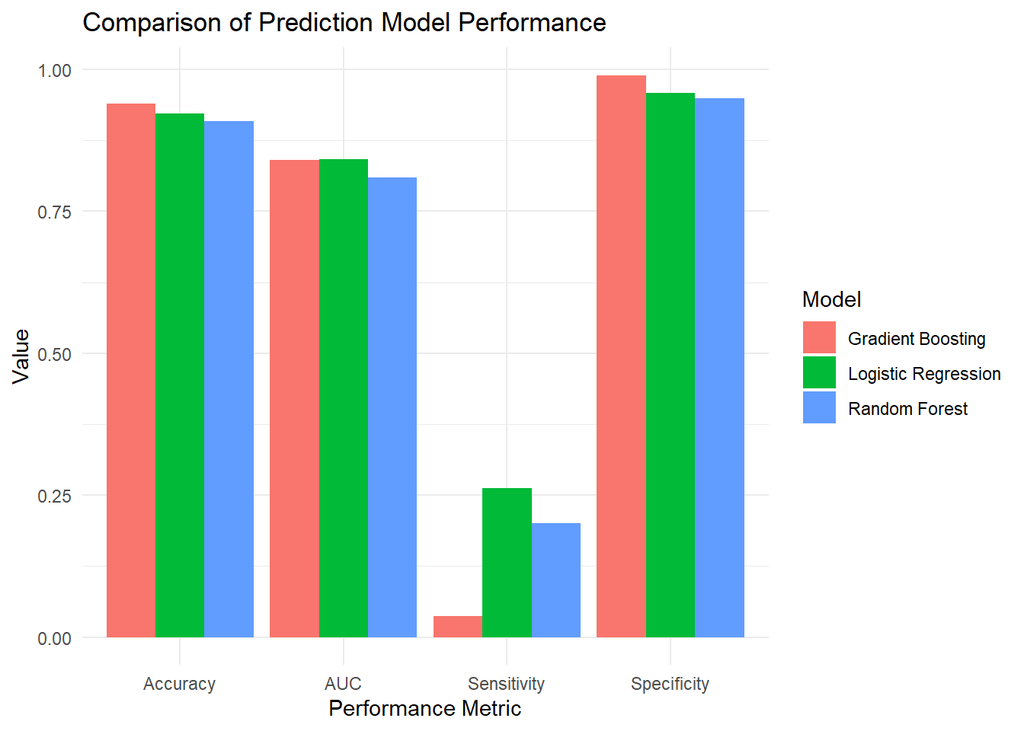

```r
comparison_long <- model_comparison %>%
  pivot_longer(
    cols = c(Accuracy, Sensitivity, Specificity, AUC),
    names_to = "Metric",
    values_to = "Value"
  )
ggplot(comparison_long, aes(x = Metric, y = Value, fill = Model)) +
  geom_bar(stat = "identity", position = "dodge") +
  labs(
    title = "Comparison of Prediction Model Performance",
    x = "Performance Metric",
    y = "Value"
  ) +
  theme_minimal()
```